# Netflix_Analysis

### Step 1 : Importing the libraries and dataset :

```python
!git clone https://github.com/HarshvardhanSingh-13/Datasets
```

```
Cloning into 'Datasets'...
remote: Enumerating objects: 347, done.
remote: Counting objects: 100% (105/105), done.
remote: Compressing objects: 100% (90/90), done.
^C
```

```python
import pandas as pd
import numpy as np
import matplotlib.pyplot as plt
import seaborn as sns
from wordcloud import WordCloud as wc
```

```python
data = pd.read_csv('/content/Datasets/Netflix_Titles Dataset/netflix_titles.csv')
```

### Step 2 : Overview of the dataset :

```python
data.head(2)
```

|  | show_id | type | title | director | cast | country | date_added | release_year | rating | duration | listed_in | description |
| --- | --- | --- | --- | --- | --- | --- | --- | --- | --- | --- | --- | --- |
| 0 | s1 | TV Show | 3% | NaN | João Miguel, Bianca Comparato, Michel Gomes, R... | Brazil | August 14, 2020 | 2020 | TV-MA | 4 Seasons | International TV Shows, TV Dramas, TV Sci-Fi &... | In a future where the elite inhabit an island ... |
| 1 | s2 | Movie | 7:19 | Jorge Michel Grau | Demián Bichir, Héctor Bonilla, Oscar Serrano, ... | Mexico | December 23, 2016 | 2016 | TV-MA | 93 min | Dramas, International Movies | After a devastating earthquake hits Mexico Cit... |

```python
data.info()
```

```
<class 'pandas.core.frame.DataFrame'>
RangeIndex: 7787 entries, 0 to 7786
Data columns (total 12 columns):
 #   Column        Non-Null Count  Dtype
---  ------        --------------  -----
 0   show_id       7787 non-null   object
 1   type          7787 non-null   object
 2   title         7787 non-null   object
 3   director      5398 non-null   object
 4   cast          7069 non-null   object
 5   country       7280 non-null   object
 6   date_added    7777 non-null   object
 7   release_year  7787 non-null   int64
 8   rating        7780 non-null   object
 9   duration      7787 non-null   object
 10  listed_in     7787 non-null   object
 11  description   7787 non-null   object
dtypes: int64(1), object(11)
memory usage: 730.2+ KB
```

```python
data.describe()
```

|  | release_year |
| --- | --- |
| count | 7787.000000 |
| mean | 2013.932580 |
| std | 8.757395 |
| min | 1925.000000 |
| 25% | 2013.000000 |
| 50% | 2017.000000 |
| 75% | 2018.000000 |
| max | 2021.000000 |

### Step 3 : Data Cleaning and Transformation :

GOAL :

- To correct the columns director , cast , rating and country as they contain null values.
- date column change for better time series operations and analysis .

```python
data.isnull().sum()
```

|  | 0 |
| --- | --- |
| show_id | 0 |
| type | 0 |
| title | 0 |
| director | 2389 |
| cast | 718 |
| country | 507 |
| date_added | 10 |
| release_year | 0 |
| rating | 7 |
| duration | 0 |
| listed_in | 0 |
| description | 0 |

**dtype:** int64

```python
# 1. handling the missing in director and cast columns :
# fill those nan values with unknown because we cannot
# really the guess the names with modes or median .
# empty cells cause problems which is why we're filling them

data['cast'].fillna('unknown' , inplace = True)
data['director'].fillna('unknown' , inplace = True)
```

```python
# 2. the empty values in countries can be filled with mode
# or with empty value

data['country'] = data['country'].fillna(data['country'].mode()[0])
```

```python
# 3. dropping the missing rows of date_added and ratings is safer option
# since the number of those is small

data.dropna(subset = ['date_added' , 'rating'] , inplace = True)
```

```python
# 4. convert date_added to datetype column

data['date_added'] = pd.to_datetime(data['date_added'] , format = 'mixed' , dayfirst = False )
```

```python
# 5. extracting the year and month in which the movie was added :

data['year_added'] = data['date_added'].dt.year
data['month_added'] = data['date_added'].dt.month
```

```python
data.head(2)
```

|  | show_id | type | title | director | cast | country | date_added | release_year | rating | duration | listed_in | description | year_added | month_added |
| --- | --- | --- | --- | --- | --- | --- | --- | --- | --- | --- | --- | --- | --- | --- |
| 0 | s1 | TV Show | 3% | unknown | João Miguel, Bianca Comparato, Michel Gomes, R... | Brazil | 2020-08-14 | 2020 | TV-MA | 4 Seasons | International TV Shows, TV Dramas, TV Sci-Fi &... | In a future where the elite inhabit an island ... | 2020 | 8 |
| 1 | s2 | Movie | 7:19 | Jorge Michel Grau | Demián Bichir, Héctor Bonilla, Oscar Serrano, ... | Mexico | 2016-12-23 | 2016 | TV-MA | 93 min | Dramas, International Movies | After a devastating earthquake hits Mexico Cit... | 2016 | 12 |

### Step 4 : Exploratory Data Analysis :

```python
# distribution of content type ?

data['type'].value_counts()
```

| type | count |
| --- | --- |
| Movie | 5372 |
| TV Show | 2398 |

**dtype:** int64

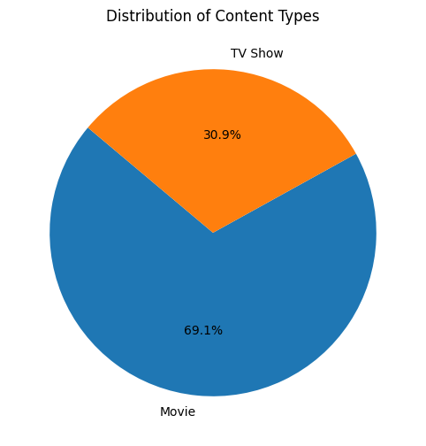

```python
plt.figure(figsize = (8,6))
plt.pie(data['type'].value_counts() ,
        labels = data['type'].value_counts().index ,
        autopct = '%1.1f%%',
        startangle = 140 )
plt.title('Distribution of Content Types')
plt.show()
```

Insights :

- movies largely dominate the platform .

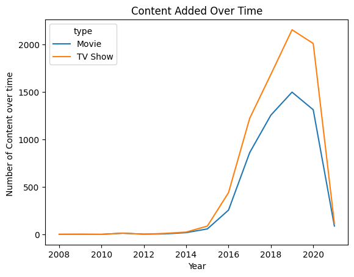

```python
# how has the content been added over time ?

content_over_time = data.groupby(['year_added' , 'type']).size().unstack().fillna(0)

plt.figure(figsize = (14,8))

content_over_time.plot(kind = 'line' , stacked = True)
plt.title('Content Added Over Time')
plt.xlabel('Year')
plt.ylabel('Number of Content over time ')
plt.show()
```

#### **Theoretical Concept: Handling Multi-Value Text Columns**

The `listed_in` column contains strings with multiple genres separated by commas (e.g., "Dramas, International Movies"). To analyze each genre individually, we need to transform the data. A common technique is to:

1. **Split** the string in each row into a list of genres.
2. **Explode** the DataFrame so that each genre in the list gets its own row, duplicating the other information for that title. This allows us to perform a `value_counts()` on the genres.

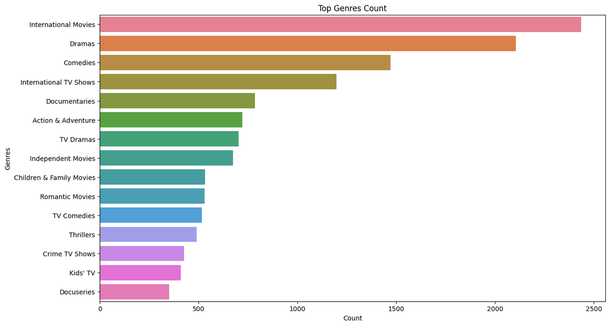

```python
# most popular genres (top 15) ?

genres = data.assign(genre = data['listed_in'].str.split(', ')).explode('genre')

top_genres_count = genres['genre'].value_counts().reset_index()
top_genres_count.columns = ['Genres' , 'Count']

# top 15 :
top_genres_count.head(15)
# how has the content been added over time ?

plt.figure(figsize = (14,8))

sns.barplot(y = 'Genres' , x = 'Count' , data= top_genres_count.head(15), hue = 'Genres', weights = 'Count')
plt.title('Top Genres Count')
plt.xlabel('Count')
plt.ylabel('Genres')
plt.show()
```

**Insights :**

- The top 5 content consists of international content , comedies , and dramas . This showcases audience's tastes reflecting in the distribution .

```python
# distribution of content duration ?

# 1. separate movies and tv shows :
movies = data[data['type'] == 'Movie']
tv_shows = data[data['type'] == 'TV Show']
```

```python
movies['duration'] = movies['duration'].str.replace(' min' , '').astype('int')
tv_shows['duration'] = tv_shows['duration'].str.replace(' Seasons' , '').str.replace( ' Season', '').astype('int')
```

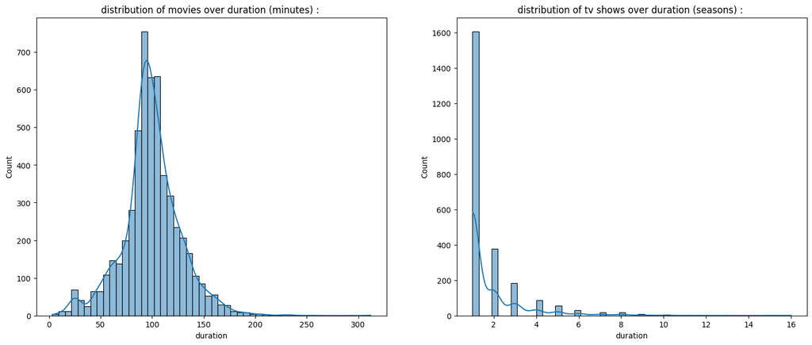

```python
# plotting the distribution :
fig , axes = plt.subplots(1,2,figsize = (18 ,7))

# movies duration distribution :
sns.histplot(ax = axes[0] , data = movies , x = 'duration' , bins = 50 , kde = True ).set_title('distribution of movies over duration (minutes) : ')
# tv shows disstribution :
sns.histplot(ax = axes[1] , data = tv_shows , x = 'duration' , bins = 50 , kde = True ).set_title('distribution of tv shows over duration (seasons) : ')
plt.show()
```

**Insights :**

- majority of the movies seems to lie in the between 80 to 120 minute duration range
- majority of the tv shows are short lived till one season .

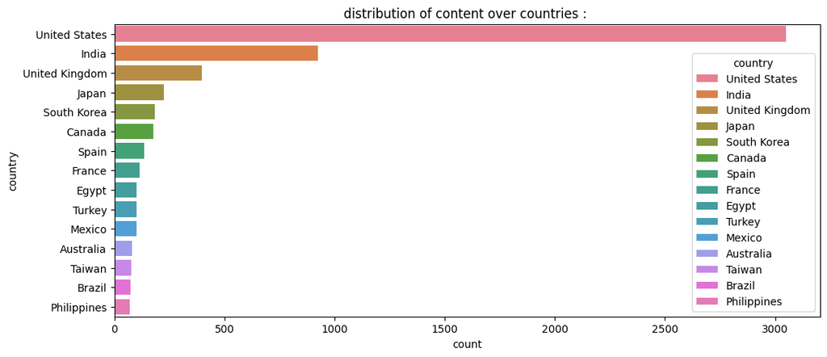

```python
# where does the content come from ? (geographical analysis) :
# top 15 countries for that :

plt.figure(figsize = (12 , 5))
top_15_countries = data.country.value_counts().head(15).reset_index()
top_15_countries.columns = ['country' , 'count']

sns.barplot(  x = 'count' , y = 'country' ,
            data = top_15_countries , hue = 'country' ,
            legend = True ).set_title('distribution of content over countries : ')
plt.xlabel('count')
plt.ylabel('country')

plt.show()
```

**Insights :**

- USA is the largest content producer over netflix among the top 15 countries with India following .
- countries like UK , south korea and japan have their content distribution high up as well , showcasing their global adaptation by the netflix audience .

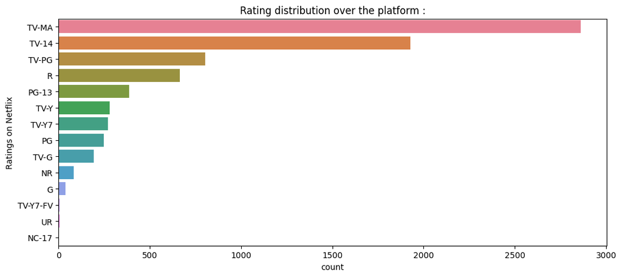

```python
# what are the maturity ratings of the contents ?

plt.figure(figsize = (12 , 5))
maturity_ratings = data.rating.value_counts().reset_index()
maturity_ratings.columns = ['rating' , 'count']

sns.barplot(data = maturity_ratings , x= 'count' , y = 'rating' , hue = 'rating').set_title('Rating distribution over the platform :')
plt.xlabel('count')
plt.ylabel('Ratings on Netflix')

plt.show()
```

**Insights :**

- Most of the content uploaded on netflix lies in the category 'TV-MA' (content for Mature Audiences) meaning .
- second highest category is 'TV-14' , for viewers of age 14 and above .
- The top 5 categories suggest that most of the content uploaded contains violence (verbal / physical / sexual) , abuse , and content that is not suitable for viewer under 18 years of age (even if they are marked as fit for 14 and above) .
- The categories of these contents also suggest that majority of audience lie in the age of range 15 and above , which also promotes the uploads of such content on the platform .

### Step 5 : Feature Engineering

Let's create a new feature to analyze how old content is when it gets added to Netflix. This can tell us about their acquisition strategy (buying old classics vs. releasing new originals).

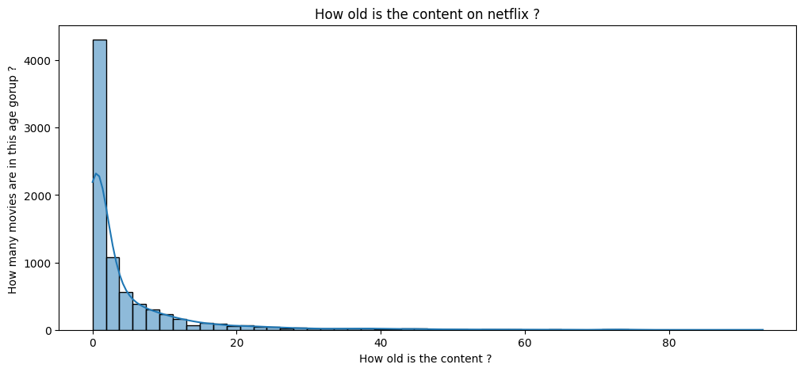

```python
# plotting the content age graph :
data['content_age'] = data['year_added'] - data['release_year']
content_age = data[data['content_age'] >= 0 ]
plt.figure(figsize = (12 ,5))

sns.histplot(data = content_age , x = 'content_age' , bins = 50 , kde = True ).set_title("How old is the content on netflix ?")
plt.xlabel('How old is the content ? ')
plt.ylabel('How many movies are in this age gorup ? ')

plt.show()
```

**Insights :**

- majority of the content seem to have been released on netlfix or released and uploaded on netfix in the same year . This is characteristic of its 'Netflix Originals' .
- The tail extends farther than 80 ,showing that netlfix also invest in uploading content that decades old , showing that it also stores 'classic' films and shows .

### Step 6 : Deeper Multivariate Analysis

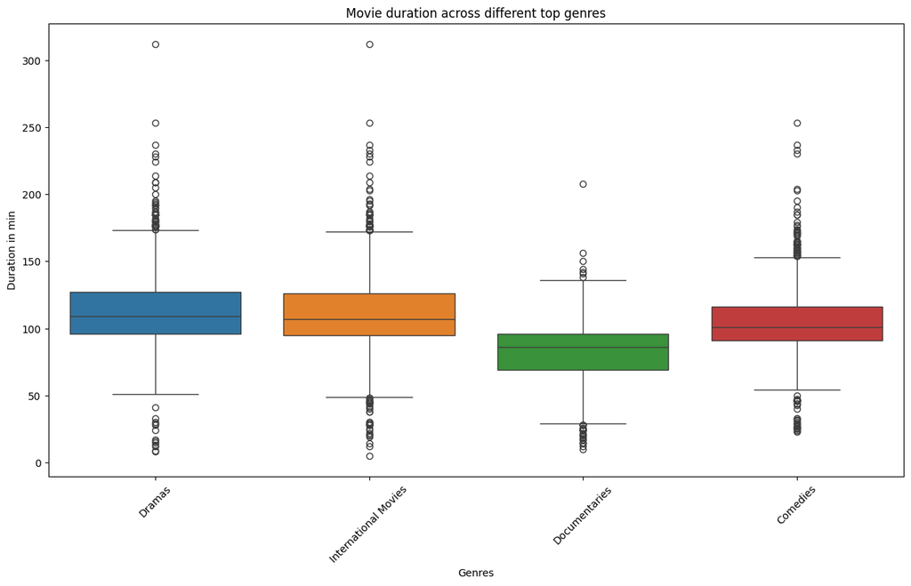

```python
# Movie duration across different top genres ?

top_5_genres = genres.genre.value_counts().index[:5]
top_genres_movies = genres[(genres['type'].str.lower() == 'movie') & (genres['genre'].isin(top_5_genres))].copy()
top_genres_movies['duration_min'] = top_genres_movies['duration'].str.replace(' min' , '' ).astype(int)

plt.figure(figsize = (15,8) )
sns.boxplot(data = top_genres_movies , x = 'genre' , y = 'duration_min' ,hue = 'genre' ,  ).set_title('Movie duration across different top genres')
plt.xlabel('Genres')
plt.ylabel('Duration in min')
plt.xticks(rotation = 45)
plt.show()
```

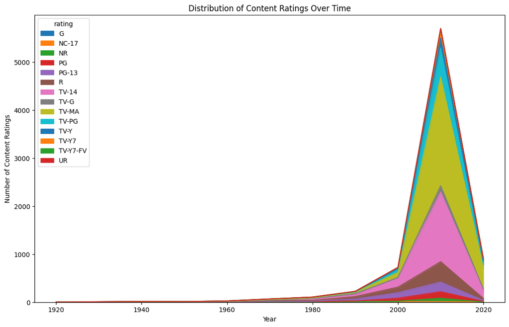

```python
# How has the distribution of content ratings changed over time?


df_copy = data.copy()
# created a new column that stores decades
# instead of individual year for better understanding
df_copy['decade'] = (df_copy['release_year'] // 10 ) * 10
# grouped by decade and rating then unstacked it for visual building
rating_year = df_copy.groupby(['decade' , 'rating']).size().unstack(fill_value = 0 )

# area plot shows how much of all the elements have increased over every decade :
rating_year.plot(kind = 'area' , stacked = True , figsize = (13 ,8) )
plt.title('Distribution of Content Ratings Over Time')
plt.xlabel('Year')
plt.ylabel('Number of Content Ratings')

plt.show()
```

**Insights :**

- Before 1980 : The ratings are really less to infer , likely because content from this time is in quantity than the newly released content on the platform .
- After 1980 : In this time , there has been an enormous increase in the content rated as 'TV-MA' , 'TV-14' ,and 'TV-PG'. This shows that over time , content rated in this categroy were added more as compared to "R" , 'PG-13' , 'UR' , and 'NC-17' .

This shows that Netflix prioritized adding more adult rated content . They claim their is to cater to diverse audiences and promote artistic appeal .However viewers say otherwise , claiming it is unnecessary .

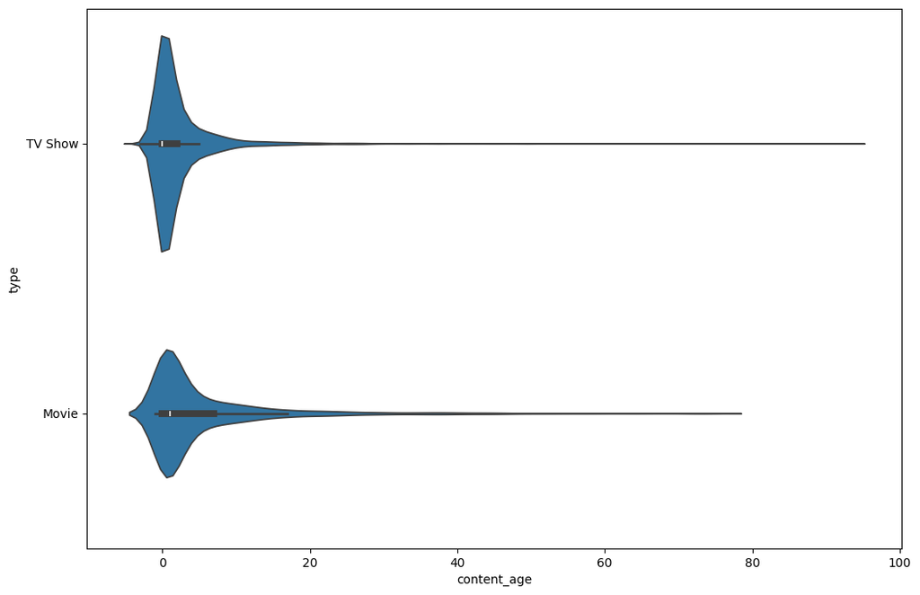

```python
# Is there a relationship between content age and its type (Movie vs. TV Show)?

plt.figure(figsize = (12,8))
sns.violinplot(data = data , y = 'type' , x = 'content_age')
plt.show()
```

**Insights :**

- Teh difference of time between addition of content and its relase is not much (~0) .This implies for both movies and TV-shows .
- We can say that newly released content is more likely to get uploaded on the Netflix platform . Specially TV-shows.

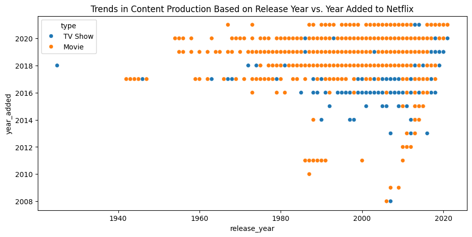

```python
# Can we identify any trends in content production
# based on the release year vs. the year added to Netflix

plt.figure(figsize = (11 , 5))
sns.scatterplot(data = data , x = 'release_year', y = 'year_added' , hue = 'type')
plt.title('Trends in Content Production Based on Release Year vs. Year Added to Netflix')

plt.show()
```

**Insights :**

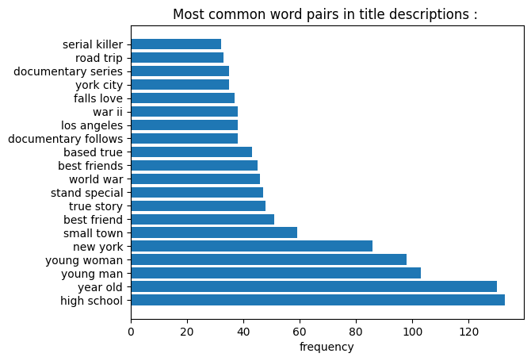

```python
# What are the most common word pairs or phrases in content descriptions?

# would have to do a bit of NLP for that :
from sklearn.feature_extraction.text import CountVectorizer as cv

df_copy= data.copy()
desc = df_copy['description'].dropna().str.lower()

# creating bigrams (pair of two words)
vect = cv( stop_words = 'english' , ngram_range = (2,2) )
X = vect.fit_transform(desc)
sum_words = X.sum(axis=0)

words_freq = [(word, sum_words[0, idx])
              for word, idx in vect
              .vocabulary_.items()]

words_freq = sorted(words_freq, key=lambda x: x[1], reverse=True)

top_phrases_bi = words_freq[:20]

# print(top_phrases_bi)

# visualising them :

phrases = [i[0] for i in top_phrases_bi]
count = [i[1] for i in top_phrases_bi]

plt.barh(phrases , count)
plt.xlabel('frequency')
plt.title('Most common word pairs in title descriptions : ')

plt.show()
```

**Insights :**

eg : 'a 20 year old young woman is determined to make a place in the bustling city of new york' This attracts 20 yo female viewers .

Therefore we can say that netflix is more aligned towards adding content that includes stories inspired by real events ,is violent ('serial killer', 'world war' , 'war ii') , has the plot based in LA or NY cities , and has characters mainly from high school . It also contains documentary films as well.

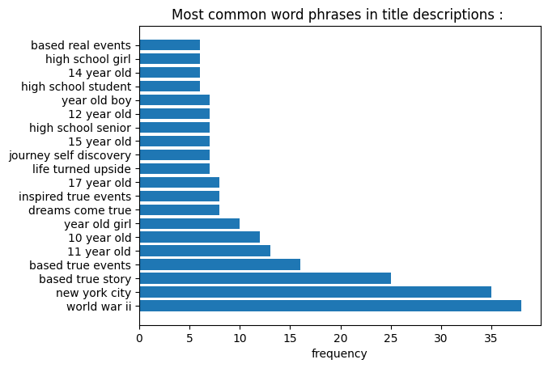

```python
#  creating trigrams (three words at a time) :
vect = cv( stop_words = 'english' , ngram_range =(3,3) )
X = vect.fit_transform(desc)
sum_words = X.sum(axis=0)

words_freq = [(word, sum_words[0, idx])
              for word, idx in vect
              .vocabulary_.items()]

words_freq = sorted(words_freq, key=lambda x: x[1], reverse=True)

top_phrases_tri = words_freq[:20]

# visualising them :

phrases = [i[0] for i in top_phrases_tri]
count = [i[1] for i in top_phrases_tri]

plt.barh(phrases , count)
plt.xlabel('frequency')
plt.title('Most common word phrases in title descriptions : ')

plt.show()
```

**Insights :**

- Phrases like '10 year old' , '11 year old' are among the top most repeated phrases . This also shows similarities with the other phrase like '12/14/15/17 year old' . this means that most of the content includes actors in between ages 12 and 17 years old .
- Among the top phrases also includes 'based true events/story' meaning that most of the content prodcued consists of real life stories or inspirations .
- 'world war ii' is the most used phrases of all the phrases . This shows that content depicted times from the world war ii period .

Overall , we can conclude that most of the content includes teenage actors , real life story replication or inspiration , stories presented in the new york city or people from new york city , and hints of world war ii.

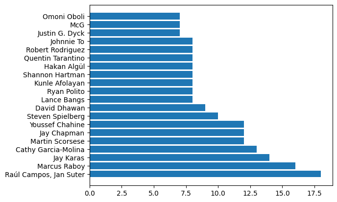

```python
# Who are the top directors on Netflix?
# 1. filtering out the 'unknown's from the director's column :
dir_graph = data[data['director'] != 'unknown'].director
dir_graph =dir_graph.value_counts().head(20).reset_index()
dir_graph.columns = ['director' , 'count']
dir_graph.head()

# 2. plotting them on a barplot :
plt.barh( dir_graph['director'] , dir_graph['count'] )

plt.show()
```

**Insights :**

- Top five include : 'Martin Scorcese' ,'Jay Karas' ,'Marcus Raboy'(american) ,Cathy Garcia-Molina (filipino) , 'raul campos' and 'jan suter' (mexican)

### Step 7 : Word Cloud from Content Descriptions

Generating a word cloud for a visual analysis from the `description` column to see what themes and words are the most common on Netflix .

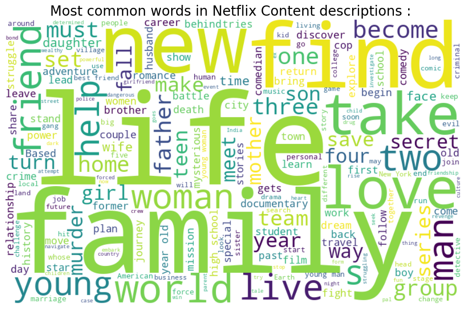

```python
text = ' '.join(data.description)
wordcloud = wc(width = 800 , height = 500 , background_color = 'white').generate(text)

# displaying the generated image :
plt.figure(figsize = (12 , 8) )
plt.imshow(wordcloud , interpolation = 'bilinear')
plt.axis('off')
plt.title('Most common words in Netflix Content descriptions : ' , fontsize = 20)
plt.show()
```

**Insights :**

- Words like 'love' , 'life' , 'world' , family' , 'friend' were used often in content descriptions showcasing that most of the content showcases human relationships .
- Words like 'new' , 'find' and 'help' can also be seen suggesting the inlcusion of mystery content as well .

### Final Conclusion and Summary of Insights :

- **Content Strategy :** Netflix's library is mostly movie-heavy (~70%) , and agressively added content between 2016 - 2019 . This includes majority of the content being newly released as well as classic , decades old shows and movies .
- **US's Domination :** US is the largest contributor to the Netflix content database . Indian content follows .
- **Rating :** The uploaded content is largely categorised and listed for mature audiences (TV-MA) and for viewers above 14 (TV-14).
- **Duration :** A huge portion of the movies lie in the duration of 80 to 120 min while majority of the TV-shows contain only one season . This shows a high-risk high-reward approach to series production .
- **Theme :** A large portion of the content have themes revolving aroung concepts of love , family , friendships etc .

There is a limitation : This dataset is about the supply of the content and not the popularity or demand of the content on the platform .